# Python-2

## accumulating

```python
sum = 0
for x in range(20):
    sum = sum + x
print(sum)
```

```
190
```

```python
sentence = 'Now is the time for all good me to come to the aid of their party'
words = sentence.split()
sum = 0
for x in words:
    print(x,len(x))
    sum = sum + len(x)
print('Total length is',sum)
```

```
Now 3
is 2
the 3
time 4
for 3
all 3
good 4
me 2
to 2
come 4
to 2
the 3
aid 3
of 2
their 5
party 5
Total length is 50
```

```python
# iterating over files
import pandas as pd
for file in ['../data/gapminder_gdp_africa.csv','../data/gapminder_gdp_asia.csv']:
    data = pd.read_csv(file,index_col='country')
    print(file, data['gdpPercap_1957'].idxmin())
```

```
../data/gapminder_gdp_africa.csv Lesotho
../data/gapminder_gdp_asia.csv Myanmar
```

## reading a directory

glob gives access to UNIX wild cards

```python
from glob import glob
```

```python
for file in glob('../data/*gdp*.csv'):
    data = pd.read_csv(file,index_col='country')
    print(file, data['gdpPercap_1957'].idxmin())
```

```
../data/gapminder_gdp_americas.csv Dominican Republic
../data/gapminder_gdp_europe.csv Bosnia and Herzegovina
../data/gapminder_gdp_oceania.csv Australia
../data/gapminder_gdp_africa.csv Lesotho
../data/gapminder_gdp_asia.csv Myanmar
```

```python
for file in glob('../data/*gdp*.csv'):
    data = pd.read_csv(file,index_col='country')
    continent = file.split('_')[2].split('.')[0].upper()
    print(continent, '\nPoorest in 1957:',data['gdpPercap_1957'].idxmin(),'\nRichest in 1957',data['gdpPercap_1957'].idxmax(),'\n\n')
```

```
AMERICAS
Poorest in 1957: Dominican Republic
Richest in 1957 United States


EUROPE
Poorest in 1957: Bosnia and Herzegovina
Richest in 1957 Switzerland


OCEANIA
Poorest in 1957: Australia
Richest in 1957 New Zealand


AFRICA
Poorest in 1957: Lesotho
Richest in 1957 South Africa


ASIA
Poorest in 1957: Myanmar
Richest in 1957 Kuwait
```

## nested loops

```python
for fruit in ['apple','pear','grape']:
    for color in ['green','orange','yellow']:
        print('I wish I had a ',color,fruit)
```

```
I wish I had a  green apple
I wish I had a  orange apple
I wish I had a  yellow apple
I wish I had a  green pear
I wish I had a  orange pear
I wish I had a  yellow pear
I wish I had a  green grape
I wish I had a  orange grape
I wish I had a  yellow grape
```

## putting some stuff together:

```
- string operations to extract the continent from the file name
- making a column name
```

```python
for file in glob('../data/*gdp*.csv'):
    for year in ['1957','2002']:
        data = pd.read_csv(file,index_col='country')
        continent = file.split('_')[2].split('.')[0].upper()
        key = 'gdpPercap_'+year
        print(continent, '\nPoorest in '+year+':',data[key].idxmin(),'\nRichest in '+year+':',data[key].idxmax(),'\n\n')
```

```
AMERICAS
Poorest in 1957: Dominican Republic
Richest in 1957: United States


AMERICAS
Poorest in 2002: Haiti
Richest in 2002: United States


EUROPE
Poorest in 1957: Bosnia and Herzegovina
Richest in 1957: Switzerland


EUROPE
Poorest in 2002: Albania
Richest in 2002: Norway


OCEANIA
Poorest in 1957: Australia
Richest in 1957: New Zealand


OCEANIA
Poorest in 2002: New Zealand
Richest in 2002: Australia


AFRICA
Poorest in 1957: Lesotho
Richest in 1957: South Africa


AFRICA
Poorest in 2002: Congo Dem. Rep.
Richest in 2002: Gabon


ASIA
Poorest in 1957: Myanmar
Richest in 1957: Kuwait


ASIA
Poorest in 2002: Myanmar
Richest in 2002: Singapore
```

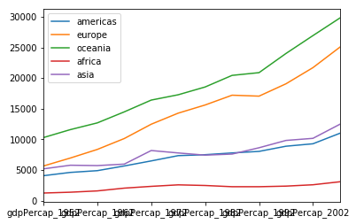

```python
import glob
import pandas as pd
import matplotlib.pyplot as plt
fig, ax = plt.subplots(1,1)
for filename in glob.glob('../data/gapminder_gdp*.csv'):
    dataframe = pd.read_csv(filename)
    # extract <region> from the filename, expected to be in the format 'data/gapminder_gdp_<region>.csv'.
    # we will split the string using the split method and `_` as our separator,
    # retrieve the last string in the list that split returns (`<region>.csv`),
    # and then remove the `.csv` extension from that string.
    region = filename.split('_')[-1][:-4]
    dataframe.mean().plot(ax=ax, label=region)
plt.legend()
plt.show()
```

## Functions

We have seen many examples of built-in functions (print, math functions, read_csv, etc are all functions). You can make your own function: takes certain inputs (arguments) and returns a value.

```python
def print_date(year, month, day):
    joined = str(year)+'/'+str(month)+'/'+str(day)
    print(joined)
```

```python
print_date(2007,11,31)
```

```
2007/11/31
```

## You can return the value for use in other computations

```python
def format_date(year,month,day):
    joined = str(year)+'/'+str(month)+'/'+str(day)
    return joined
```

```python
format_date(2007,12,10)
```

```
'2007/12/10'
```

```python
dates = []
for year in range(2007,2010):
    for month in range(5, 8):
        for day in range(12,20):
            dates.append(format_date(year,month,day))
```

```python
dates
```

```
['2007/5/12',
 '2007/5/13',
 '2007/5/14',
 '2007/5/15',
 '2007/5/16',
 '2007/5/17',
 '2007/5/18',
 '2007/5/19',
 '2007/6/12',
 '2007/6/13',
 '2007/6/14',
 '2007/6/15',
 '2007/6/16',
 '2007/6/17',
 '2007/6/18',
 '2007/6/19',
 '2007/7/12',
 '2007/7/13',
 '2007/7/14',
 '2007/7/15',
 '2007/7/16',
 '2007/7/17',
 '2007/7/18',
 '2007/7/19',
 '2008/5/12',
 '2008/5/13',
 '2008/5/14',
 '2008/5/15',
 '2008/5/16',
 '2008/5/17',
 '2008/5/18',
 '2008/5/19',
 '2008/6/12',
 '2008/6/13',
 '2008/6/14',
 '2008/6/15',
 '2008/6/16',
 '2008/6/17',
 '2008/6/18',
 '2008/6/19',
```

[output cut: 17 more lines]

```
 '2009/6/13',
 '2009/6/14',
 '2009/6/15',
 '2009/6/16',
 '2009/6/17',
 '2009/6/18',
 '2009/6/19',
 '2009/7/12',
 '2009/7/13',
 '2009/7/14',
 '2009/7/15',
 '2009/7/16',
 '2009/7/17',
 '2009/7/18',
 '2009/7/19']
```

## functions and data analysis

Recall that we worked with the pandas dataframe `gapminder_data.csv`.

```python
import matplotlib.pyplot as plt
plt.style.use('ggplot')
```

```python
data = pd.read_csv('../data/gapminder_data.csv',index_col='country')
```

```python
percapita = pd.pivot_table(data,index='country',columns='year',values='gdpPercap')
```

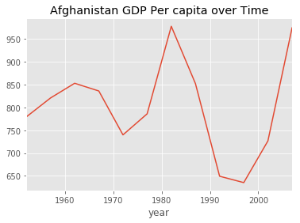

```python
percapita.loc['Afghanistan'].plot(title='Afghanistan GDP Per capita over Time')
```

```python
def country_gdp(country):
    title = country + ' GDP Per Capita over Time'
    percapita.loc[country].plot(figsize=(8,8),legend=True,title='GDP Per Capita')
```

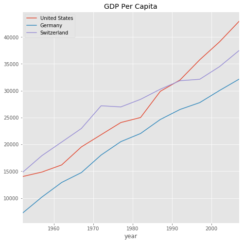

```python
country_gdp("United States")
country_gdp("Germany")
country_gdp("Switzerland")
```

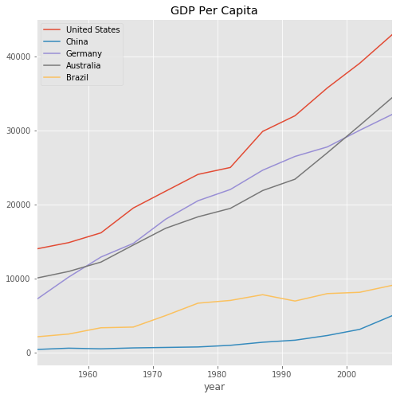

```python
for country in ['United States','China','Germany','Australia','Brazil']:
    country_gdp(country)
```

## A random walk

```python
import numpy.random as rnd
```

```python
x = rnd.choice([-1,1])
```

```python
def random_walk(N):
    spot = 0
    L = []
    for i in range(N):
        spot = spot + rnd.choice([-1,1])
        L.append(spot)
    return L
```

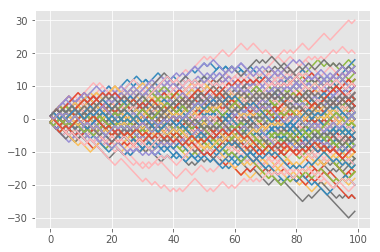

```python
end_spots = []
for i in range(200):
    walk = random_walk(100)
    plt.plot(range(100),walk)
    end_spots.append(walk[-1])
```

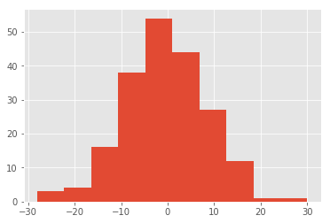

```python
s=plt.hist(end_spots,bins=10)
```

## Variable scope

variables inside functions are "local" to the function and changes to them don't last after the function ends

- the scope of a variable is the region where it is defined -- basically, in a function block and anything inside that.

```python
def lister(x):
    L = [x]*10
    v = 47
    print(L)
```

```python
print(L)
lister(4)
print(L)
```

```
[0, 1, 2, 3, 4, 5, 6, 7, 8, 9]
[4, 4, 4, 4, 4, 4, 4, 4, 4, 4]
[0, 1, 2, 3, 4, 5, 6, 7, 8, 9]
```

There are subtleties to variable scope. If a variable is NOT NAMED as an argument, then it is assumed to come from "outside" the function.

```python
L = ['a','b','c']
def j(x):
    L.append(x)
```

```python
j('u')
```

```python
L
```

```
['a', 'b', 'c', 'u']
```

And structures (like lists, and arrays) CAN be modified inside a function EVEN IF they are given as an argument.

```python
L = ['a','b','c']
def j(x,L):
    L.append(x)
j('x',L)
print(L)
```

```
['a', 'b', 'c', 'x']
```

The full set of rules is a bit complicated and we won't go into all the details.

## Conditionals

```python
def my_abs(x):
    if x<0:
        return -x
    else:
        return x
```

```python
my_abs(-1)
```

```
1
```

This function returns a "tuple" which is a pair of lists. You can get the two lists with subscripts or with the A, B = construction

```python
def split_threshold(threshold,L):
    Low = []
    High = []
    for item in L:
        if item<threshold:
            Low.append(item)
        else:
            High.append(item)
    return Low, High
```

```python
T = split_threshold(0,[-1,-5,2,-13,11,100])
print(T)
```

```
([-1, -5, -13], [2, 11, 100])
```

```python
print(T[0])
```

```
[-1, -5, -13]
```

```python
print(T[1])
```

```
[2, 11, 100]
```

This is the syntax for unpacking a tuple

```python
Low, High = split_threshold(0,[-1,-5,2,-13,11,100])
```

```python
Low
```

```
[-1, -5, -13]
```

```python
High
```

```
[2, 11, 100]
```

Python admits and and or operators

```python
data['pop'].head()
```

```
country
Afghanistan     8425333.0
Afghanistan     9240934.0
Afghanistan    10267083.0
Afghanistan    11537966.0
Afghanistan    13079460.0
Name: pop, dtype: float64
```

```python
for x in 'Jeremy Teitelbaum':
    if (x>='r' and x<='u'):
        print(x)
```

```
r
t
u
```

# applying a function in pandas

```python
population_size(300000000)
```

[output not shown]

[output not shown]

```
'medium'
```

```python
data['pop_class']=data['pop'].apply(population_size)
```

```python
data.head()
```

| country | year | pop | continent | lifeExp | gdpPercap | pop_class |
| --- | --- | --- | --- | --- | --- | --- |
| Afghanistan | 1952 | 8425333.0 | Asia | 28.801 | 779.445314 | small |
| Afghanistan | 1957 | 9240934.0 | Asia | 30.332 | 820.853030 | small |
| Afghanistan | 1962 | 10267083.0 | Asia | 31.997 | 853.100710 | medium |
| Afghanistan | 1967 | 11537966.0 | Asia | 34.020 | 836.197138 | medium |
| Afghanistan | 1972 | 13079460.0 | Asia | 36.088 | 739.981106 | medium |

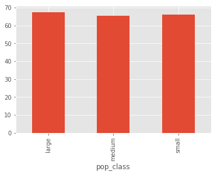

```python
data[(data['year']==2002)].groupby('pop_class')['lifeExp'].mean().plot(kind='bar')
```

```python
def life_exp_by_class_and_year(year):
    data[(data['year']==2002)].groupby('pop_class')['lifeExp'].mean().plot(kind='bar')
```

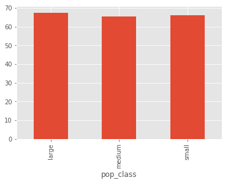

```python
life_exp_by_class_and_year(1957)
```

```python
data[(data['year']==2002) & (data['pop_class'] == 'large')]
```

| country | year | pop | continent | lifeExp | gdpPercap | pop_class |
| --- | --- | --- | --- | --- | --- | --- |
| China | 2002 | 1.280400e+09 | Asia | 72.028 | 3119.280896 | large |
| India | 2002 | 1.034173e+09 | Asia | 62.879 | 1746.769454 | large |

## docstrings

```python
def threshold(x,L):
    """Returns (Low, High) where Low is the list of elements in L less than x,
    and High is a list of those greater than or equal to x"""
    Low, High = [], []
    for item in L:
        if item<x:
            Low.append(item)
        else:
            High.append(item)
    return Low, High
```

```python
?threshold
```

```
Signature: threshold(x, L)
Docstring:
Returns (Low, High) where Low is the list of elements in L less than x,
and High is a list of those greater than or equal to x
File:      ~/GitHub/Carpentries/2020-01-13/notes/<ipython-input-254-5a9844fcc62c>
Type:      function
```

## default arguments

```python
def threshold(L,x=0):
    """Returns (Low, High) where Low is the list of elements in L less than x,
    and High is a list of those greater than or equal to x.  x defaults to zero."""
    Low, High = [], []
    for item in L:
        if item<x:
            Low.append(item)
        else:
            High.append(item)
    return Low, High
```

```python
threshold([1,-3,2,5])
```

```
([-3], [1, 2, 5])
```

```python
?threshold
```

```
Signature: threshold(L, x=0)
Docstring:
Returns (Low, High) where Low is the list of elements in L less than x,
and High is a list of those greater than or equal to x.  x defaults to zero.
File:      ~/GitHub/Carpentries/2020-01-13/notes/<ipython-input-256-bc8a5db254e7>
Type:      function
```

```python
?print
```

```
Docstring:
print(value, ..., sep=' ', end='\n', file=sys.stdout, flush=False)

Prints the values to a stream, or to sys.stdout by default.
Optional keyword arguments:
file:  a file-like object (stream); defaults to the current sys.stdout.
sep:   string inserted between values, default a space.
end:   string appended after the last value, default a newline.
flush: whether to forcibly flush the stream.
Type:      builtin_function_or_method
```